# LTOM.01.002 Data Analysis in Community Ecology

## 8.6 Phylogenetic tree

Similarly to functional distances, we can also use phylogenetic distances between taxa. These distances basically represent the latest time when two taxa had a common ancestor (i.e. when they diverged). We will use the packages `ape` and `phytools`.

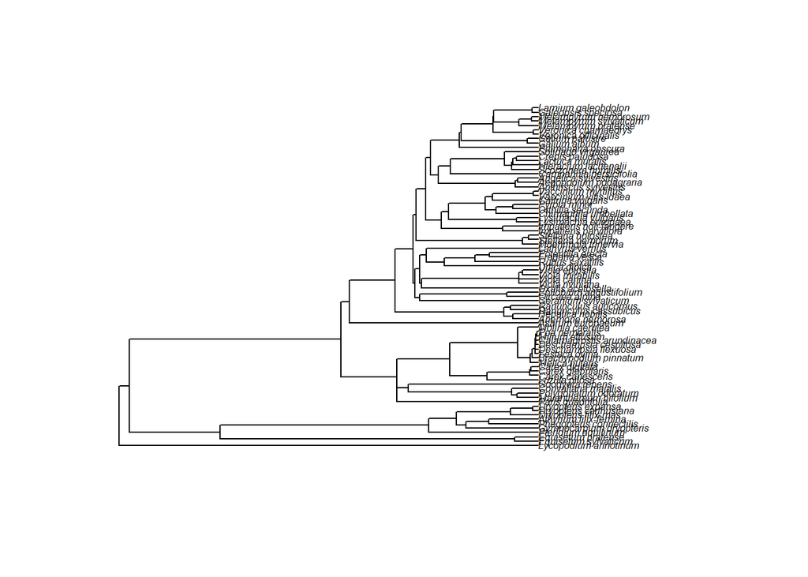

```r
library(ape)

phy <- read.tree("phy.tree.newick.txt")

plot(phy, cex = 0.5)  # not easy to read
```

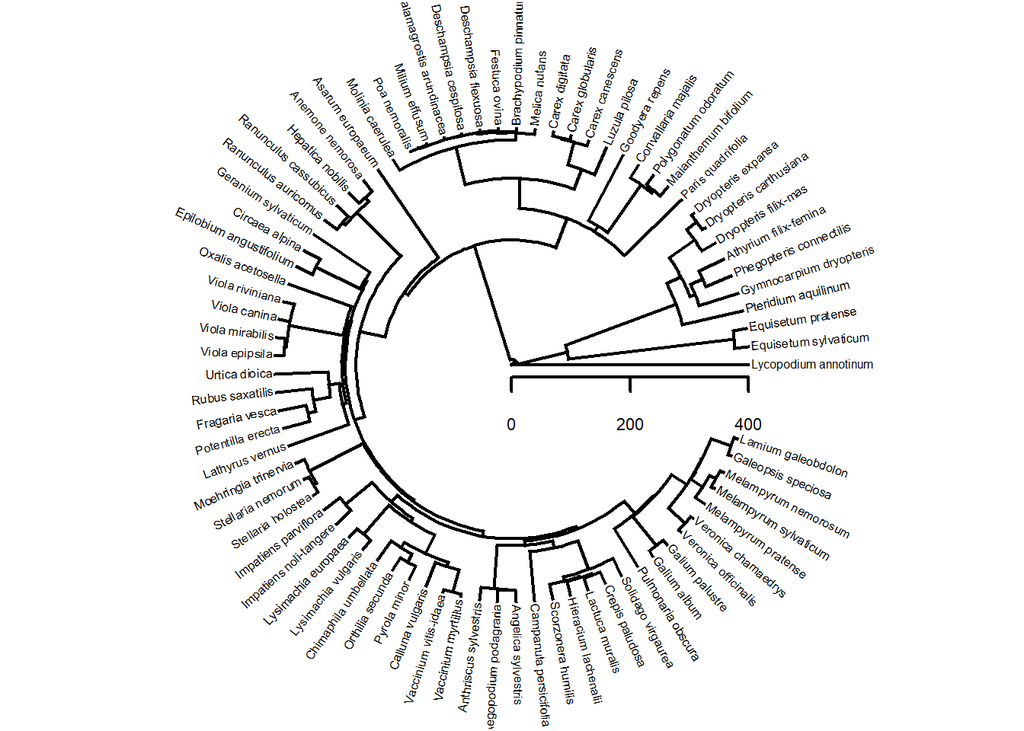

```r
# A circular plot

library(phytools)
plotTree(phy, type = "fan", part = 0.95, fsize = 0.5)
h <- round(max(nodeHeights(phy)) / 10) * 10
axis(1, pos = -0.05 * h, at = seq(0, h, by = h / 2), lwd = 2, cex.axis = 0.7)
```

```r
# NB! Axis with millions of years (up to 400 millions)
```

## 8.7 Phylogenetic diversity

We can estimate the phylogenetic distance between all pairs of species and use again the `melodic` function to calculate phylogenetic diversity.

```r
# The first thing to check is whether the names of species in the tree and the abundance matrix match:
phy$tip.label
```

```
##  [1] "Lycopodium_annotinum"      "Equisetum_sylvaticum"
##  [3] "Equisetum_pratense"        "Pteridium_aquilinum"
##  [5] "Gymnocarpium_dryopteris"   "Phegopteris_connectilis"
##  [7] "Athyrium_filix-femina"     "Dryopteris_filix-mas"
##  [9] "Dryopteris_carthusiana"    "Dryopteris_expansa"
## [11] "Paris_quadrifolia"         "Maianthemum_bifolium"
## [13] "Polygonatum_odoratum"      "Convallaria_majalis"
## [15] "Goodyera_repens"           "Luzula_pilosa"
## [17] "Carex_canescens"           "Carex_globularis"
## [19] "Carex_digitata"            "Melica_nutans"
## [21] "Brachypodium_pinnatum"     "Festuca_ovina"
## [23] "Deschampsia_flexuosa"      "Deschampsia_cespitosa"
## [25] "Calamagrostis_arundinacea" "Milium_effusum"
## [27] "Poa_nemoralis"             "Molinia_caerulea"
## [29] "Asarum_europaeum"          "Anemone_nemorosa"
```

[output cut: 24 more lines]

```r
colnames(vas.plants)
```

```
##  [1] "ACTAspic"   "AEGOpoda"   "ANEMnemo"   "ASAReuro"   "ATHYfil.fe"
##  [6] "BRACpinn"   "CALAarun"   "CALLvulg"   "CAREdigi"   "CIRCalpi"
## [11] "CONVmaja"   "DESCflex"   "DRYOcart"   "DRYOexpa"   "EPILangu"
## [16] "FESTovin"   "FRAGvesc"   "GALElute"   "GERAsylv"   "GYMNdryo"
## [21] "HEPAnobi"   "IMPAnoli"   "LATHvern"   "LUZUpilo"   "LYCOanno"
## [26] "MAIAbifo"   "MELAprat"   "MELInuta"   "MILIeffu"   "MOLIcaer"
## [31] "MYCEmura"   "ORTHsecu"   "OXALacet"   "PARIquad"   "PTERaqui"
## [36] "RANUcass"   "RUBUsaxa"   "STELholo"   "STELnemo"   "TRIEeuro"
## [41] "VACCmyrt"   "VACCvit.id" "VEROcham"   "VIOLmira"   "ANGEsylv"
## [46] "ANTHsylv"   "CAMPpers"   "CAREcane"   "CAREglob"   "CHIMumbe"
## [51] "CREPpalu"   "DESCcaes"   "DRYOfili"   "EQUIprat"   "EQUIsylv"
## [56] "GALEOPsp"   "GALIalbu."  "GALIpalu"   "GOODrepe"   "HIERvulg"
## [61] "IMPAparv"   "LYSIvulg"   "MELAnemo"   "MELAsylv"   "MOERtrin"
## [66] "PHEGconn"   "POAnemo"    "POLYodor"   "POTEerec"   "PULMobsc"
## [71] "PYROmino"   "RANUauri."  "SCORhumi"   "SOLIvirg"   "URTIdioi"
## [76] "VEROoffi"   "VIOLcani"   "VIOLepip"   "VIOLrivi."
```

```r
# They dont. The first problem is that the names in the abundance matrix are
# shortened, showing the first four characters of the genus in CAPITAL letters and
# the first four characters of the epiteton in small letters.
# Lets transform the names from the phylogeny:
new.names <- character()
for(i in 1:length(phy$tip.label)){
  separateNames <- strsplit(phy$tip.label[i], split  = "_")[[1]]
  separateNames[1] <- toupper(separateNames[1])
  new.names[i] <- paste0(substr(separateNames[1], 1, 4),
                         substr(separateNames[2], 1, 4))
}
# We can now replace names in the phylogeny:
phy$tip.label <- new.names

# The next issue is with the column names. Some species have a dot (".") which we
# dont want to keep:
colnames2 <- gsub(pattern = "\\.", replacement = "", x = colnames(vas.plants))
#There is a species with an extra character (9 instead of 8).  Lets trim them all:
colnames2 <- substr(colnames2, 1, 8)
# Now lets substitute colnames:
colnames(vas.plants) <- colnames2

#Not all species in the phylogeny are in the community matrix, and vice versa.
# Lets keep only common species:
vas.plants2 <- vas.plants[, which(colnames2 %in% phy$tip.label)]
phy2 <- drop.tip(phy, tip = setdiff(phy$tip.label, colnames2))

#Finally, lets reorder columns so that the species match the names order in the phylogeny:
vas.plants2 <- vas.plants2[, phy2$tip.label]

# Distance within tree
phy.dis <- cophenetic(phy2) # distance between tree tips!

phy.mpd <- melodic(vas.plants2, phy.dis)$presence$mpd

phy.mpd
```

```
##  [1] 387.20367 271.45177 294.67478 461.78523 296.81682 557.92382 365.86018
##  [8] 516.32730  70.20136 352.97152 462.00656 392.54300 444.89736 376.17377
## [15] 408.73964 434.16348 419.69530 422.80277 314.98768 420.57579 580.14899
## [22] 345.41456 278.04621 420.47415 404.45586 306.59898 295.91345 436.52068
## [29] 502.32523 505.32190
```

NB! You can use cophenetic distance for any (dis)similarity tree (community composition, trait similarity of species, etc.).

> Test whether phylogenetic mpd is related to species richness. How is it related to functional mpd?

**Answer**

```r
shapiro.test(phy.mpd) # OK
```

```
##
##  Shapiro-Wilk normality test
##
## data:  phy.mpd
## W = 0.94619, p-value = 0.1336
```

```r
cor.test(rowSums(vas.plants2>0),phy.mpd)
```

```
##
##  Pearson's product-moment correlation
##
## data:  rowSums(vas.plants2 > 0) and phy.mpd
## t = 1.1955, df = 28, p-value = 0.2419
## alternative hypothesis: true correlation is not equal to 0
## 95 percent confidence interval:
##  -0.1519618  0.5379331
## sample estimates:
##       cor
## 0.2203722
```

```r
cor.test(phy.mpd,mpd,method="spearman") # mpd was not normally distributed
```

```
##
##  Spearman's rank correlation rho
##
## data:  phy.mpd and mpd
## S = 5190, p-value = 0.413
## alternative hypothesis: true rho is not equal to 0
## sample estimates:
##        rho
## -0.1546162
```

## 8.8 Community assembly tests with traits

With traits and phylogeny we can make community assembly tests. These tests check if functional trait values or phylogenetic history are randomly assembled in a community, or if taxa are more similar (or dissimilar) than expected by chance. If there are more similar species, then often it has been explained by habitat filtering (similar taxa fits to similar habitats). On the other hand, when co-existing species are more dissimilar than expected, it has been explained by competition – similar species compete most strongly and might exclude each other.

```r
mpd <- melodic(vas.plants.traits > 0, trait.dist, "abundance")$abundance$mpd

mpd.rand <- replicate(100,
                      melodic(apply(vas.plants.traits > 0, 2, sample),
                              trait.dist, "abundance")$abundance$mpd)

## Function replicate makes the same thing n times (here 100)
## Functions apply and sample randomize all taxa across all samples

mean.rand <- apply(mpd.rand, 1, mean, na.rm = T) # mean random functional diversity

sd.rand <- apply(mpd.rand, 1, sd, na.rm = T) # standard deviation

ses <- (mpd - mean.rand) / sd.rand # SES = standardized effect size, calculated from
# observed and randomized values, is usually normally distributed, values >1.96 and < -1.96 are significant.

abs(ses) > 1.96
```

```
##  [1] FALSE FALSE FALSE FALSE FALSE  TRUE FALSE FALSE FALSE FALSE FALSE FALSE
## [13] FALSE FALSE FALSE FALSE FALSE FALSE FALSE FALSE  TRUE FALSE FALSE FALSE
## [25] FALSE FALSE FALSE FALSE  TRUE FALSE
```

```r
# We can visualize this by making histograms of random functional diversities and showing the observed value as a line.

i = 1 #sample ID
hist(mpd.rand[i, ], xlim = range(mpd.rand[i, ], mpd[i]), main = "",
  xlab = "Random functional diversity")
abline(v = mpd[i], col = "red", lwd = 3)
mtext("Obs.", 3, at = mpd[i], col = "red") # mtext writes text outside the figure box

# P-value can be calculated as proportion of random observations more extreme than the empirical value

p <- sum(mpd[i] < mpd.rand[i,]) / length(mpd.rand[i,])
p # one side
```

```
## [1] 0.38
```

```r
1 - p # another side
```

```
## [1] 0.62
```

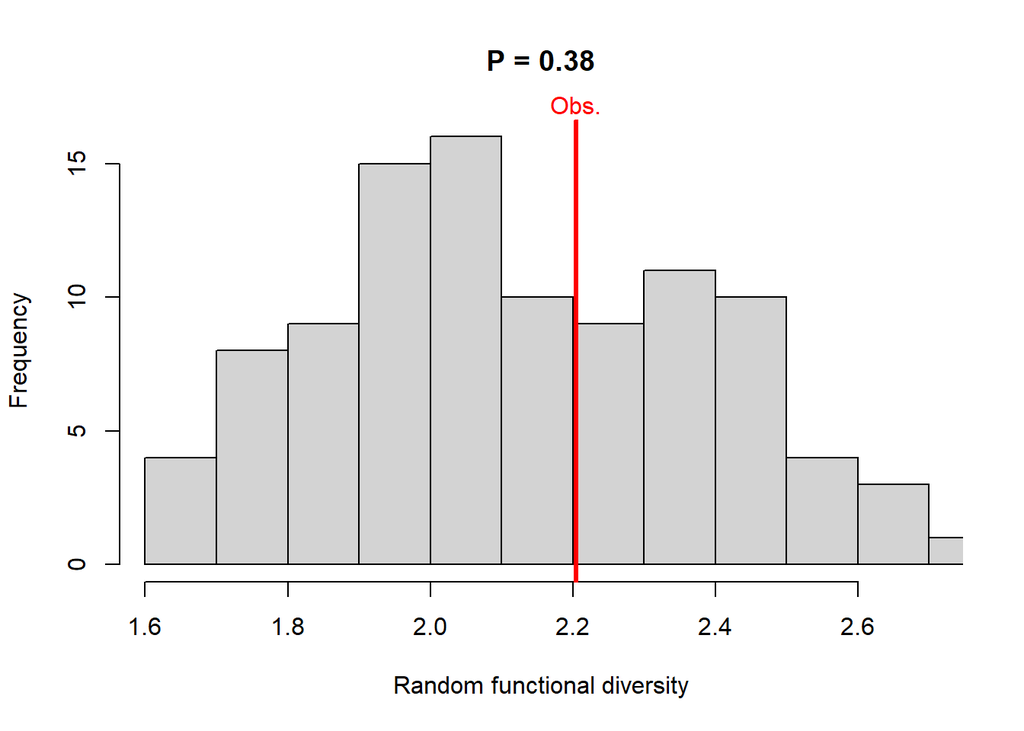

```r
title(main = paste("P =", round(min(p, 1 - p), 3)))
```

> Make the histogram for site no 3.

**Answer**

```r
i=3 #sample ID
hist(mpd.rand[i,],xlim=range(mpd.rand[i,],mpd[i]),main="",xlab="Random functional diversity")
abline(v=mpd[i],col="red",lwd=3)
mtext("Obs.",3,at=mpd[i],col="red") # mtext writes text outside the figure box
p=sum(mpd[i]<mpd.rand[i,])/length(mpd.rand[i,])
p # one side
```

```
## [1] 0.08
```

```r
1-p # another side
```

```
## [1] 0.92
```

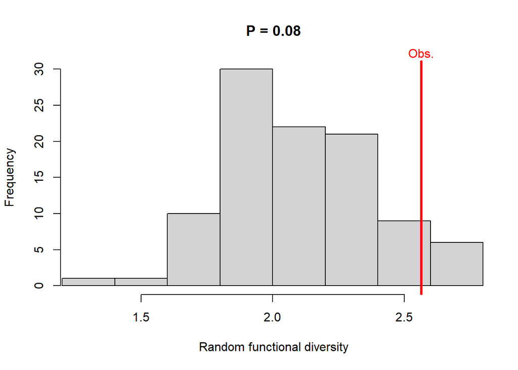

```r
title(main=paste("P =",round(min(p,1-p),3)))
```

## 8.9 Richness variance over all samples

Another community assembly test does not require traits or phylogeny. It just compares the variance in richness values with a null model where species are distributed randomly across samples (by keeping empirical species frequencies).

If observed variation is smaller than random expectation, then competition might limit the number of taxa. If the observed variation is larger, we likely have different species pools for different sites, some are larger than others.

```r
var.obs <- var(rowSums(vas.plants > 0))
var.obs
```

```
## [1] 33.62759
```

```r
random.table <- apply(vas.plants > 0, 2, sample)

var(rowSums(random.table))
```

```
## [1] 7.351724
```

```r
var.rand <- replicate(100, var(rowSums(apply(vas.plants > 0, 2, sample))))

hist(var.rand, xlim = range(var.rand, var.obs), main = "", col = "blue")

abline(v = var.obs, col = "red", lwd = 3)
mtext("Obs.", 3, at = var.obs, col = "red")

p <-  sum(var.obs < var.rand) / length(var.rand)
p # one side
```

```
## [1] 0
```

```r
1 - p # another side
```

```
## [1] 1
```

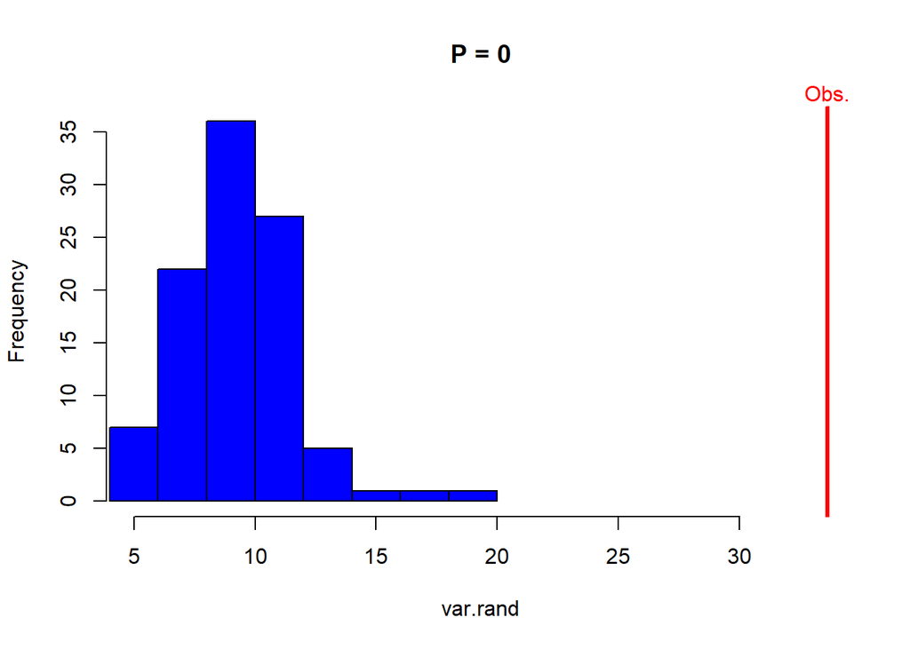

```r
title(main = paste("P =", round(min(p, 1 - p), 3)))
```